# Season summary: 4545 League, Season 9

### Overview

- The season ran from 5 Sep 2017 to 29 Oct 2017.
- 197 players took part, playing 506 games in total. 93 games were either forfeited or set as scheduling draws.
- Across the season, White won 215 games (42.5%), 86 games (17%) were drawn, and Black won 205 games (40.5%).
- 330 games ended with a resignation, 85 games by checkmate, 4 games by time running out, and 3 games by stalemate.

### Standings

Link: https://www.lichess4545.com/team4545/season/9/standings/

#### Final podium

| 1st place | 2nd place | 3rd place |
| --- | --- | --- |
| Bad News Bishops | Stormy Knights | Scotch on the Rooks |
| Napoleon_Solo | eie24 | morallygray |
| udaysatya | PsiMaster | SpiteKnight |
| roso97 | gyrating_kairos | yago666 |
| OuterHeaven92 | deepblueincarnate | tnan123 |
| rb52 | qrs | deanmadden |
| GetAGripWhitby | haggismcbean | mn8 |
| haggismcbean | Rascar_Capac | revhas |
| mn8 |  | MMichael |
| Plasterhippy |  | nathanj439 |

[output cut: 1 more lines]

#### Story of the season

[figure not shown]

#### Top performers by board

*Only shown for 4545 stats*

| Board | Player | Games | Points | Board Perf. |
| --- | --- | --- | --- | --- |
| 1 | lovlas | 7 | 6.5 | 2591.71428571429 |
| 1 | tomek188 | 7 | 5.5 | 2427.42857142857 |
| 1 | tipau | 7 | 5.5 | 2359.71428571429 |
| 1 | hetraie | 8 | 6 | 2353.25 |
| 1 | MeBeKa | 6 | 4.5 | 2351.33333333333 |
| 2 | Axp156 | 4 | 3.5 | 2281.5 |
| 2 | TMaus | 7 | 6 | 2262.71428571429 |
| 2 | morallygray | 6 | 4.5 | 2177.66666666667 |
| 2 | quirked | 7 | 5.5 | 2174.28571428571 |
| 2 | Lord_axe | 6 | 4 | 2127.16666666667 |

[output cut: 20 more lines]

### Summary charts

#### Match results (4545 only)

[figure not shown]

#### When were games played?

[figure not shown]

#### How long did games take?

[figure not shown]

### Longest games

#### By moves

*Includes games ranked at or above the 90th percentile by number of moves.*

| Rank | Players / Link | Date | Moves |
| --- | --- | --- | --- |
| 1 | Immortality - qrs | Thu 12 Oct 2017 | 119 |
| 2 | Groundhopping - ErinYu | Sat 21 Oct 2017 | 95 |
| 3 | Lelouch_Vi_Brittania - MeBeKa | Thu 19 Oct 2017 | 89 |
| 4 | fradtheimpaler - Mooserohde | Sat 23 Sep 2017 | 85 |
| 5 | eie24 - tomek188 | Sat 21 Oct 2017 | 81 |
| 6 | Staincastle - Dmathman | Sat 30 Sep 2017 | 78 |
| 7 | chesswithcoach - redban | Wed 27 Sep 2017 | 75 |
| 8 | john465 - JMHWSM | Sat 28 Oct 2017 | 75 |
| 9 | scurly - loukas435 | Sat 23 Sep 2017 | 73 |
| 10 | loukas435 - Tellum | Sun 17 Sep 2017 | 73 |

[output cut: 45 more lines]

#### By total time

*Includes games ranked at or above the 90th percentile by total time.*

| Rank | Players / Link | Date | Total time |
| --- | --- | --- | --- |
| 1 | Immortality - qrs | Thu 12 Oct 2017 | 3h 35m 34.397s |
| 2 | Groundhopping - ErinYu | Sat 21 Oct 2017 | 3h 13m 13.519s |
| 3 | eie24 - tomek188 | Sat 21 Oct 2017 | 3h 10m 52.121s |
| 4 | Staincastle - Dmathman | Sat 30 Sep 2017 | 3h 7m 51.43s |
| 5 | Lelouch_Vi_Brittania - MeBeKa | Thu 19 Oct 2017 | 3h 7m 5.349s |
| 6 | Lichie - kobol | Sun 22 Oct 2017 | 3h 3m 24.741s |
| 7 | morallygray - Lord_axe | Sun 15 Oct 2017 | 3h 2m 49.6s |
| 8 | ErinYu - kobol | Sat 9 Sep 2017 | 3h 2m 36.755s |
| 9 | TCGRIF - Staincastle | Sun 8 Oct 2017 | 2h 59m 59.971s |
| 10 | loukas435 - Tellum | Sun 17 Sep 2017 | 2h 58m 16.403s |

[output cut: 45 more lines]

### Stats by board / rating band

#### ACPLs / blunder rates

[figure not shown]

#### Games with lowest combined ACPL

The games with the lowest combined ACPL (including draws).

| Board | Players / Link | Result | Sum ACPL | Date |
| --- | --- | --- | --- | --- |
| 1 | Sonata2 - ErinYu | 1/2-1/2 | 16 | Fri 27 Oct 2017 |
| 1 | badplayer_CM - lovlas | 0-1 | 16 | Thu 12 Oct 2017 |
| 2 | Axp156 - GnarlyGoat | 1/2-1/2 | 24 | Thu 19 Oct 2017 |
| 3 | Hackov - revoof | 1/2-1/2 | 19 | Fri 6 Oct 2017 |
| 4 | RuizBR - Dmathman | 1/2-1/2 | 20 | Thu 26 Oct 2017 |
| 5 | MichaelPren95 - SpiteKnight | 1/2-1/2 | 23 | Thu 28 Sep 2017 |
| 6 | qrs - flandoo | 0-1 | 31 | Thu 14 Sep 2017 |

#### Excl. draws

The *decisive* games with the lowest combined ACPL.

| Board | Players / Link | Result | Sum ACPL | Date |
| --- | --- | --- | --- | --- |
| 1 | badplayer_CM - lovlas | 0-1 | 16 | Thu 12 Oct 2017 |
| 2 | Pushedpawn - CaptNCarter | 0-1 | 27 | Sat 16 Sep 2017 |
| 3 | yago666 - pioki | 1-0 | 37 | Sat 21 Oct 2017 |
| 4 | GogoYubari - Wolf21 | 1-0 | 27 | Sun 29 Oct 2017 |
| 5 | Dmathman - dose7781 | 1-0 | 46 | Fri 22 Sep 2017 |
| 6 | qrs - flandoo | 0-1 | 31 | Thu 14 Sep 2017 |

### Openings

#### Popular openings

All openings played in the season, excluding variations.

| Rank | Opening | Games | White's score (%) | White wins (%) | Draws (%) | Black wins (%) | Mean eval after 15 moves | Avg rating |
| --- | --- | --- | --- | --- | --- | --- | --- | --- |
| 1 | Sicilian Defense | 67 | 42.5373134328358 | 34.3283582089552 | 16.4179104477612 | 49.2537313432836 | 0.263230769230769 | 1829.58208955224 |
| 2 | French Defense | 32 | 46.875 | 40.625 | 12.5 | 46.875 | 0.0787096774193548 | 1774.40625 |
| 3 | Caro-Kann Defense | 31 | 37.0967741935484 | 35.4838709677419 | 3.2258064516129 | 61.2903225806452 | -0.616451612903226 | 1759.41935483871 |
| 4 | Ruy Lopez | 30 | 45 | 40 | 10 | 50 | 0.877666666666667 | 1826.4 |
| 5 | Indian Defense | 28 | 51.7857142857143 | 46.4285714285714 | 10.7142857142857 | 42.8571428571429 | 0.525 | 1851.30357142857 |
| 6 | King's Indian Defense | 27 | 51.8518518518518 | 44.4444444444444 | 14.8148148148148 | 40.7407407407407 | 0.82962962962963 | 1850.01851851852 |
| 7 | English Opening | 25 | 56 | 44 | 24 | 32 | 1.12041666666667 | 1841.18 |
| 8 | Queen's Pawn Game | 24 | 50 | 37.5 | 25 | 37.5 | 0.218181818181818 | 1758.27083333333 |
| 9 | Nimzo-Indian Defense | 22 | 59.0909090909091 | 45.4545454545455 | 27.2727272727273 | 27.2727272727273 | 0.0580952380952381 | 1853.81818181818 |
| 10 | Slav Defense | 20 | 52.5 | 40 | 25 | 35 | 0.657894736842105 | 1848.575 |

[output cut: 47 more lines]

#### Popular variations

All openings played in the season, including variations.

| Rank | Opening | Games | White's score (%) | White wins (%) | Draws (%) | Black wins (%) | Mean eval after 15 moves | Avg rating |
| --- | --- | --- | --- | --- | --- | --- | --- | --- |
| 1 | Indian Defense | 13 | 61.5384615384615 | 61.5384615384615 | 0 | 38.4615384615385 | 0.783846153846154 | 1844.80769230769 |
| 2 | Queen's Pawn Game: Mason Variation | 10 | 60 | 50 | 20 | 30 | 0.9325 | 1658.2 |
| 3 | Caro-Kann Defense | 6 | 50 | 50 | 0 | 50 | -0.39 | 1754.91666666667 |
| 4 | Scandinavian Defense: Mieses-Kotroc Variation | 6 | 58.3333333333333 | 50 | 16.6666666666667 | 33.3333333333333 | 2.56166666666667 | 1999.58333333333 |
| 5 | King's Indian Defense: Normal Variation, Rare Defenses | 5 | 50 | 40 | 20 | 40 | -0.01 | 1853.4 |
| 6 | Pirc Defense | 5 | 40 | 40 | 0 | 60 | 4.286 | 1700 |
| 7 | Sicilian Defense: Alapin Variation | 5 | 60 | 40 | 40 | 20 | 0.268 | 1710.5 |
| 8 | Sicilian Defense: Modern Variations | 5 | 60 | 60 | 0 | 40 | -0.526 | 1589.3 |
| 9 | Grünfeld Defense: Exchange Variation, Modern Exchange Variation | 4 | 62.5 | 50 | 25 | 25 | -0.2125 | 1837.75 |
| 10 | Italian Game: Classical Variation, Giuoco Pianissimo | 4 | 37.5 | 25 | 25 | 50 | -0.025 | 2197.875 |

[output cut: 310 more lines]

#### Best for White

The best-scoring main openings for White.

*Includes all main openings played in at least 10 games.*

| Rank | Opening | Games | White's score (%) | White wins (%) | Draws (%) | Black wins (%) | Mean eval after 15 moves | Avg rating |
| --- | --- | --- | --- | --- | --- | --- | --- | --- |
| 1 | Scandinavian Defense | 16 | 62.5 | 50 | 25 | 25 | 1.23125 | 1902.375 |
| 2 | Nimzo-Indian Defense | 22 | 59.0909090909091 | 45.4545454545455 | 27.2727272727273 | 27.2727272727273 | 0.0580952380952381 | 1853.81818181818 |
| 3 | Queen's Gambit Declined | 19 | 57.8947368421053 | 47.3684210526316 | 21.0526315789474 | 31.5789473684211 | 0.460526315789474 | 1713.68421052632 |
| 4 | English Opening | 25 | 56 | 44 | 24 | 32 | 1.12041666666667 | 1841.18 |
| 5 | Slav Defense | 20 | 52.5 | 40 | 25 | 35 | 0.657894736842105 | 1848.575 |
| 6 | King's Indian Defense | 27 | 51.8518518518518 | 44.4444444444444 | 14.8148148148148 | 40.7407407407407 | 0.82962962962963 | 1850.01851851852 |
| 7 | Indian Defense | 28 | 51.7857142857143 | 46.4285714285714 | 10.7142857142857 | 42.8571428571429 | 0.525 | 1851.30357142857 |
| 8 | Queen's Pawn Game | 24 | 50 | 37.5 | 25 | 37.5 | 0.218181818181818 | 1758.27083333333 |
| 9 | French Defense | 32 | 46.875 | 40.625 | 12.5 | 46.875 | 0.0787096774193548 | 1774.40625 |
| 10 | Pirc Defense | 11 | 45.4545454545455 | 36.3636363636364 | 18.1818181818182 | 45.4545454545455 | 2.68636363636364 | 1834.63636363636 |

[output cut: 4 more lines]

#### Best for Black

The best-scoring main openings for Black.

*Includes all main openings played in at least 10 games.*

| Rank | Opening | Games | Black's score (%) | Black wins (%) | Draws (%) | White wins (%) | Mean eval after 15 moves | Avg rating |
| --- | --- | --- | --- | --- | --- | --- | --- | --- |
| 1 | Caro-Kann Defense | 31 | 62.9032258064516 | 61.2903225806452 | 3.2258064516129 | 35.4838709677419 | -0.616451612903226 | 1759.41935483871 |
| 2 | Italian Game | 13 | 57.6923076923077 | 46.1538461538462 | 23.0769230769231 | 30.7692307692308 | 2.01916666666667 | 1782.80769230769 |
| 3 | Sicilian Defense | 67 | 57.4626865671642 | 49.2537313432836 | 16.4179104477612 | 34.3283582089552 | 0.263230769230769 | 1829.58208955224 |
| 4 | Ruy Lopez | 30 | 55 | 50 | 10 | 40 | 0.877666666666667 | 1826.4 |
| 5 | Pirc Defense | 11 | 54.5454545454545 | 45.4545454545455 | 18.1818181818182 | 36.3636363636364 | 2.68636363636364 | 1834.63636363636 |
| 6 | French Defense | 32 | 53.125 | 46.875 | 12.5 | 40.625 | 0.0787096774193548 | 1774.40625 |
| 7 | Queen's Pawn Game | 24 | 50 | 37.5 | 25 | 37.5 | 0.218181818181818 | 1758.27083333333 |
| 8 | Indian Defense | 28 | 48.2142857142857 | 42.8571428571429 | 10.7142857142857 | 46.4285714285714 | 0.525 | 1851.30357142857 |
| 9 | King's Indian Defense | 27 | 48.1481481481481 | 40.7407407407407 | 14.8148148148148 | 44.4444444444444 | 0.82962962962963 | 1850.01851851852 |
| 10 | Slav Defense | 20 | 47.5 | 35 | 25 | 40 | 0.657894736842105 | 1848.575 |

[output cut: 4 more lines]

#### Popular gambits

All gambit openings played in the season.

| Rank | Name | Games | White score (%) |
| --- | --- | --- | --- |
| 1 | Smith-Morra Gambit | 6 | 16.6666666666667 |
| 2 | Benko Gambit | 5 | 80 |
| 3 | King's Gambit | 3 | 66.6666666666667 |
| 4 | Geller Gambit | 2 | 50 |
| 5 | Milner-Barry Gambit | 1 | 100 |
| 6 | Staunton Gambit | 1 | 100 |
| 7 | Urusov Gambit | 1 | 50 |
| 8 | Marshall Gambit | 1 | 0 |

#### Gambiteers

The players who enjoyed the most success when playing gambits (min 50% score).

| Rank | Player | Games | % Score |
| --- | --- | --- | --- |
| 1 | eie24 | 1 | 1 |
| 2 | iongler | 1 | 1 |
| 3 | LuvGangster | 1 | 1 |
| 4 | mrjv | 1 | 1 |
| 5 | roso97 | 1 | 1 |
| 6 | Scarff | 1 | 1 |
| 7 | schubix | 1 | 1 |
| 8 | shetoo | 1 | 1 |
| 9 | gatorricky | 2 | 0.75 |
| 10 | TheRatRiverTrapper | 2 | 0.5 |

[output cut: 8 more lines]

#### Sunburst

Click on the image below to see an explorable sunburst plot of all openings played in the season.

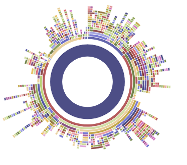

### Player awards

| Award | Description | Winner | Details | Honourable mentions |
| --- | --- | --- | --- | --- |
| x | Archbishop of Accuracy | Groundhopping | 12.3 (142) | mrjv, lovlas |
| x | Awesome Alt | haggismcbean | Played for 4 different teams | hicetnunc, liamvo, redban, RodrigoDiazdeVivar (3) |
| x | Bullet Boss | InfernalJumble | 19 | Dmathman, Chess_Patzer |
| x | David Award | jippiedoe | Opponents' record: 7/7 | CaptNCarter, Plasterhippy |
| x | Gambit Guru | eie24 | 100% from 1 games | iongler, LuvGangster |
| x | Giri Award | Lichie |  | Achieved 4 draws |
| x | Grischuk's Cousin | rsava | Had 12m 59s left in https://lichess.org/VifNaB9s#20 (eventual Win) | loukas435, mingpro |
| x | Houdini Award | flandoo |  | JohnsonBronson, morallygray |
| x | Intimate with Increment | Lelouch_Vi_Brittania | 22.9% (86/375) | YungPirc, jivey |
| x | Musing or Snoozing | Lord_axe | Spent 32m 2s on https://lichess.org/HQ4FGloN#23 | Seb32, onbion |

[output cut: 8 more lines]

### Appendix

#### Best performance ratings / highest accuracy

The following five sections present various player-based statistics. See if you can spot your name in the tables. Most tables are sortable and searchable, but also have specified inclusion criteria.

##### Best relative perfs

Shows all players who achieved a performance rating (over a minimum of 5 games) that exceeded their initial rating.

*For some reason, these performance ratings tend to differ slightly from the values that are shown on players’ Lichess4545 season profile pages. I don’t know why they’re different, but they’re similar enough that it doesn’t matter. For what it’s worth, I use FIDE’s method (which the website does too), and I ignore all unplayed games such as forfeits and scheduling draws.*

| # | Player | Games | W | D | L | Initial | Perf | Diff. |
| --- | --- | --- | --- | --- | --- | --- | --- | --- |
| 1 | flandoo | 8 | 8 | 0 | 0 | 1460 | 2297 | 837 |
| 2 | WarGoblin | 7 | 7 | 0 | 0 | 1374 | 2136.57142857143 | 762.571428571428 |
| 3 | mrjv | 6 | 6 | 0 | 0 | 1615 | 2244 | 629 |
| 4 | archone | 5 | 4 | 1 | 0 | 1888 | 2300.6 | 412.6 |
| 5 | JohnsonBronson | 7 | 6 | 1 | 0 | 1815 | 2167 | 352 |
| 6 | roso97 | 5 | 4 | 0 | 1 | 1778 | 2071 | 293 |
| 7 | Axp156 | 8 | 6 | 1 | 1 | 1879 | 2157.125 | 278.125 |
| 8 | slavy | 8 | 3 | 1 | 4 | 1198 | 1475.875 | 277.875 |
| 9 | CarlosMagnussen | 6 | 4 | 1 | 1 | 1714 | 1984 | 270 |
| 10 | MeBeKa | 6 | 4 | 1 | 1 | 2082 | 2351.33333333333 | 269.333333333333 |

[output cut: 52 more lines]

##### Lowest ACPL

*Only the top 100 players are shown. Min. 100 moves played.*

| Rank | Player | Moves | ACPL |
| --- | --- | --- | --- |
| 1 | Groundhopping | 142 | 12.3239436619718 |
| 2 | mrjv | 175 | 14.3485714285714 |
| 3 | lovlas | 271 | 17.3136531365314 |
| 4 | scurly | 173 | 20.028901734104 |
| 5 | MichaelPren95 | 150 | 20.32 |
| 6 | flandoo | 266 | 20.4285714285714 |
| 7 | RuizBR | 195 | 22.6717948717949 |
| 8 | ErinYu | 337 | 22.9406528189911 |
| 9 | Scrooge | 122 | 23.1065573770492 |
| 10 | tipau | 184 | 23.6576086956522 |

[output cut: 90 more lines]

##### Multiple single-figure ACPLs

Players with single-figure ACPLs in more than one game over the season.

| Player | Games |
| --- | --- |
| badplayer_CM | 2 |
| ErinYu | 3 |

#### Time spent, comebacks and upsets

##### Time spent

The top 50 players by total clock time spent over the season.

| Rank | Player | Games | Total time spent |
| --- | --- | --- | --- |
| 1 | InfernalJumble | 9 | 10h 57m 59s |
| 2 | YungPirc | 8 | 9h 24m 0s |
| 3 | hetraie | 8 | 9h 23m 42s |
| 4 | Lelouch_Vi_Brittania | 7 | 9h 17m 34s |
| 5 | mariuseg | 8 | 9h 16m 55s |
| 6 | Lichie | 7 | 8h 58m 8s |
| 7 | loukas435 | 7 | 8h 28m 46s |
| 8 | ErinYu | 7 | 8h 28m 22s |
| 9 | slaiyn | 8 | 8h 26m 8s |
| 10 | Immortality | 7 | 8h 23m 14s |

[output cut: 40 more lines]

##### Time spent per move (after move 10)

*This table shows everyone who played at least three games during the season.*

| Rank | Player | Games | Moves | Time spent per move | Percentile |
| --- | --- | --- | --- | --- | --- |
| 1 | GetAGripWhitby | 3 | 42 | 2m 43.7s | 100 |
| 2 | Pushedpawn | 6 | 122 | 2m 18.8s | 99 |
| 3 | isaypotato | 5 | 96 | 2m 17.8s | 98 |
| 4 | shetoo | 7 | 170 | 2m 14.9s | 97 |
| 5 | jpokerflat | 6 | 128 | 2m 13.3s | 96 |
| 6 | GogoYubari | 7 | 166 | 2m 7.3s | 95 |
| 7 | YungPirc | 8 | 237 | 2m 7.2s | 94 |
| 8 | Nombringer | 6 | 153 | 2m 6.6s | 93 |
| 9 | archone | 5 | 111 | 2m 6.5s | 92 |
| 10 | slaiyn | 8 | 178 | 2m 4.5s | 91 |

[output cut: 148 more lines]

#### Draws, comebacks, upsets

##### Most draws

The players who had the most draws over the season.

| Player | Draws |
| --- | --- |
| Lichie | 4 |

##### Comebacks

Originally suggested by **Lou-E**.

This table shows players ranked by the size and number of comebacks achieved over the course of the season.

For this purpose, the size of a comeback has been defined as the difference between a player’s final score in a game (0, 0.5, or 1) and the worst evaluation during the game that they faced (which is then converted into a rough win probability for their opponent).

For example, if I were to win a game after Lichess’s server analysis gave my opponent a 75% chance of winning in a certain position, then I would have earned 1.75 comeback “points” from the game. My opponent of course would have earned zero points. If the game had been drawn, I would have instead earned only 0.75 comeback “points”.

*Only those who played at least three games in the season and who have a positive average comeback margin are included.*

| Rank | Player | Average Comeback Margin | Total Comeback Margin |
| --- | --- | --- | --- |
| 1 | flandoo | 1.27592086383162 | 10.207366910653 |
| 2 | JohnsonBronson | 1.2228046088161 | 8.55963226171272 |
| 3 | morallygray | 1.06231883004227 | 8.49855064033813 |
| 4 | PsiMaster | 1.05372229273086 | 8.4297783418469 |
| 5 | TMaus | 1.1623437048112 | 8.1364059336784 |
| 6 | WarGoblin | 1.1320420559397 | 7.92429439157788 |
| 7 | Axp156 | 0.954529352950445 | 7.63623482360356 |
| 8 | piotor | 1.06945234384396 | 7.48616640690775 |
| 9 | tomek188 | 0.988801012729503 | 6.92160708910652 |
| 10 | Dmathman | 0.860669161864103 | 6.88535329491282 |

[output cut: 143 more lines]

##### Biggest upsets

*Includes all players who defeated an opponent rated at least 50 points higher.*

| Rank | Player | Upset Margin |
| --- | --- | --- |
| 1 | slavy | 352 |
| 2 | slavy | 293 |
| 3 | JMHWSM | 236 |
| 4 | MamaDuck | 198 |
| 5 | rhohit | 177 |
| 6 | Arkensiel | 170 |
| 7 | slavy | 164 |
| 8 | dank-chessessities | 155 |
| 9 | piotor | 150 |
| 10 | KFerapont | 147 |

[output cut: 73 more lines]

##### Repeated upsets

Includes players who achieved multiple wins over opponents rated at least 50 points higher.

| Rank | Player | Total Upset Margin | Upsets | Avg Upset Margin | Biggest Margin |
| --- | --- | --- | --- | --- | --- |
| 1 | slavy | 809 | 3 | 269.666666666667 | 352 |
| 2 | flandoo | 403 | 5 | 80.6 | 107 |
| 3 | Arkensiel | 363 | 3 | 121 | 170 |
| 4 | piotor | 219 | 2 | 109.5 | 150 |
| 5 | eie24 | 202 | 2 | 101 | 141 |
| 6 | archone | 199 | 2 | 99.5 | 116 |
| 7 | Mooserohde | 199 | 2 | 99.5 | 136 |
| 8 | loukas435 | 195 | 2 | 97.5 | 108 |
| 9 | s2004k1993 | 179 | 2 | 89.5 | 122 |
| 10 | dose7781 | 177 | 3 | 59 | 64 |

[output cut: 8 more lines]

#### Dawdlers and instant movers

##### Least time left after move 10

Originally suggested by **Silkthewanderer**.

Shows the players who had the least time remaining after their 10th move in a game.

*Includes the 100 top instances by this measure.*

| Rank | Player | Time left after 10 moves | Result | Link |
| --- | --- | --- | --- | --- |
| 1 | rsava | 12m 59s | Win | https://lichess.org/VifNaB9s#20 |
| 2 | loukas435 | 14m 5s | Win | https://lichess.org/MQSvWG60#19 |
| 3 | mingpro | 16m 52s | Win | https://lichess.org/ykD2z1bZ#19 |
| 4 | spuntachessTs | 18m 28s | Loss | https://lichess.org/VifNaB9s#19 |
| 5 | JohnsonBronson | 22m 0s | Draw | https://lichess.org/WYZKPHMz#19 |
| 6 | yago666 | 23m 30s | Win | https://lichess.org/i0cVqQOS#19 |
| 7 | TheRatRiverTrapper | 23m 38s | Win | https://lichess.org/FvbwUDMA#20 |
| 8 | Lelouch_Vi_Brittania | 24m 43s | Draw | https://lichess.org/HiRP8aFX#19 |
| 9 | Kraaft | 25m 0s | Loss | https://lichess.org/JIxfWwVa#19 |
| 10 | InfernalJumble | 25m 11s | Draw | https://lichess.org/x9Tapho0#20 |

[output cut: 90 more lines]

##### Instant moves

The players who made the most moves over the season while taking less than 0.5 seconds.

*Includes all players who made at least one such move.*

| Rank | Player | Instant moves |
| --- | --- | --- |
| 1 | InfernalJumble | 19 |
| 2 | Dmathman | 17 |
| 3 | Chess_Patzer | 16 |
| 4 | loukas435 | 15 |
| 5 | PsiMaster | 13 |
| 6 | tomek188 | 13 |
| 7 | Boviced | 11 |
| 8 | jg777 | 11 |
| 9 | krispl | 11 |
| 10 | Lichie | 11 |

[output cut: 119 more lines]

#### Longest thinks, time trouble addicts, and lucky escapes

##### Longest thinks

The longest times spent on a single move.

*Top 100 shown.*

| # | Player | Time spent | Colour | Move | Link |
| --- | --- | --- | --- | --- | --- |
| 1 | Lord_axe | 32m 2s | White | 12 | https://lichess.org/HQ4FGloN#23 |
| 2 | Seb32 | 30m 49s | Black | 15 | https://lichess.org/EAWdgv8q#30 |
| 3 | onbion | 30m 40s | White | 16 | https://lichess.org/LcjYPUZs#31 |
| 4 | InfernalJumble | 30m 24s | White | 18 | https://lichess.org/JYDIBUTX#35 |
| 5 | artykom | 26m 25s | White | 23 | https://lichess.org/ByBHpkgR#45 |
| 6 | TMaus | 24m 50s | Black | 17 | https://lichess.org/dJGHHoxv#34 |
| 7 | arex | 23m 40s | Black | 16 | https://lichess.org/m9QqW4cE#32 |
| 8 | Lord_axe | 22m 42s | Black | 34 | https://lichess.org/pmDAaZK9#68 |
| 9 | Anunzio | 22m 37s | White | 15 | https://lichess.org/R9RaMR8n#29 |
| 10 | hetraie | 22m 4s | White | 18 | https://lichess.org/JjNZLVXT#35 |

[output cut: 90 more lines]

##### Time trouble addicts

Shows players by proportion of moves made in time trouble (defined as having less than a minute remaining on the clock).

*Includes everyone who played at least 100 moves over the season while making at least one move in time trouble.*

| # | Player | All moves | With < 1min left | Time Trouble % |
| --- | --- | --- | --- | --- |
| 1 | Lelouch_Vi_Brittania | 375 | 86 | 0.229333333333333 |
| 2 | YungPirc | 315 | 72 | 0.228571428571429 |
| 3 | jivey | 208 | 46 | 0.221153846153846 |
| 4 | kobol | 295 | 62 | 0.210169491525424 |
| 6 | mingpro | 107 | 20 | 0.186915887850467 |
| 7 | gyrating_kairos | 202 | 30 | 0.148514851485149 |
| 8 | Groundhopping | 141 | 18 | 0.127659574468085 |
| 9 | Immortality | 319 | 39 | 0.122257053291536 |
| 10 | OuterHeaven92 | 147 | 17 | 0.115646258503401 |
| 11 | Fabinou | 310 | 35 | 0.112903225806452 |

[output cut: 56 more lines]

##### Saved by the bell

Games where a player moved with only 5 seconds left on their clock…and still won!

| Player | Moves with under 5s left | Link |
| --- | --- | --- |
| loukas435 | 3 | https://lichess.org/sRpI2XWH |
| Immortality | 2 | https://lichess.org/4mR8AZCK |
| loukas435 | 2 | https://lichess.org/MQSvWG60 |
| slaiyn | 2 | https://lichess.org/FfJRh0uJ |
| YungPirc | 2 | https://lichess.org/geQrhAnR |
| Lord_axe | 1 | https://lichess.org/HQ4FGloN |

#### Team stats (4545 only)

```
## # A tibble: 28 x 12
##    team                               players games pts_nonforf  wins draws losses  acpl avg_moves blunder_pc  rank points
##    <chr>                                <int> <int>       <dbl> <int> <int>  <int> <dbl>     <dbl>      <dbl> <int>  <dbl>
##  1 Bad News Bishops                        10    34        21      19     4     11  37.9      36.6     0.0273     1   28.5
##  2 Casterly Rook                            7    38        19      18     2     18  46.7      32.2     0.0393    19   23
##  3 Checkmate With Slight Advantage          6    33        17.5    14     7     12  38.8      41.9     0.0376     8   24.5
##  4 Chesster Summon Mods                     6    41        22.5    18     9     14  41.0      40.4     0.0374     7   26
##  5 Deep Thoughtless                        10    36        25.5    22     7      7  40.6      38.5     0.0303     6   27
##  6 Forked the King to Spoon the Queen       7    45        17      15     4     26  47.2      40.8     0.0409    28   18
##  7 Good Rookin Guys                         8    39        18.5    16     5     18  35.4      36.5     0.0295    22   21.5
##  8 It'll Be Alright on the Knight           9    35        15      12     6     17  40.2      37.9     0.0392    18   22
##  9 Looks Like a Majority                    7    34        19      15     8     11  37.1      38.7     0.0304     5   26.5
## 10 Mighty Morphy's Power Rangers            8    33        11.5    11     1     21  44.6      39.9     0.0440    25   18
## # ... with 18 more rows
```

#### Misc. facts

##### Lesser spotted mates

A pawn gave checkmate in 3 games: https://lichess.org/2ZMBg0A5, https://lichess.org/dudyvoAu, https://lichess.org/hnrajxqw.

A knight gave checkmate in 5 games: https://lichess.org/DOwyLFvl, https://lichess.org/CAsBO6Vc, https://lichess.org/yMXqFYx5, https://lichess.org/3AkU6Ldp, https://lichess.org/3mMApizB.

##### Promotions

62 games had at least one promotion. 3 of these saw an under-promotion.

The most promotions seen in a game was 4: https://lichess.org/VWiLglDH

##### Rollercoaster games

43 games featured significant winning chances for both sides (as identified by Lichess’s server analysis), comprising 8.5% of all games played.

##### Checks and captures

- Most consecutive checks: 12 (https://lichess.org/L2t6KiuE, https://lichess.org/T1YYZTos)
- Most consecutive captures: 10 (https://lichess.org/DTfORFBs)
- Latest-occurring first capture: ply 47 in https://lichess.org/vkpDGwBU

### About

- This report was compiled on 30 July 2021.
- It uses data on player/team pairings and results from the Lichess4545 website combined with game data provided by Lichess.
- Note that the data excludes all players who are currently banned by Lichess for violating their Terms of Service (at the time the report was compiled). This can mean that players who are listed in the final standings on the Lichess4545 website are missing from the statistics presented here.
- Although tournament performance ratings have been calculated using FIDE’s method, they may differ slightly from figures published on the Lichess4545 website.
- Currently, ties are not properly handled when determining player awards, which may cause errors.
- Also, the code that produces the stats does not implement tiebreaks to determine the top three 4545 teams. This usually works out fine, but it can lead to errors in seasons where the top positions were determined by tiebreaks – most notably in Season 11.
- Icons for player awards: [Noun Project](https://thenounproject.com/)

Stats produced by izzie26

*Want to help with the ledger? Ask in #lichessledger*